# Parallel processing GMM

Bronwyn McCall

2024-10-07

## Methods of parallel processing

1. **Socket**: launches a new version of R on each core. Technically this connection is done via networking, but the connection is happening all on your computer. If you get a warning from your computer asking whether to allow R to accept incoming connections, you should allow it. Have to use Sockets as it works on Windows.
2. **Forking**: copies the entire current version of R and moves it to a new core.

## Generating data

```r
library(parallel)
library(ggplot2)
```

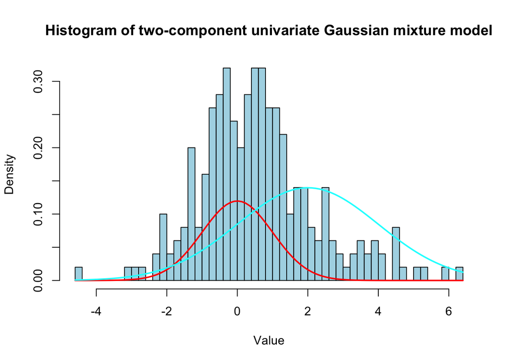

```r
set.seed(123)

# SET MODEL HYPERPARAMETERS AND SETTINGS
K <- 2 # number of components
n <- 1000 # sample size
m <- 4 # number of nodes
n_m <- n/m # sample size per node

# TRUE PARAMETERS
pi_1 <- 0.3
pi_2 <- 1 - pi_1
mu_1 <- 0
mu_2 <- 2
si_1 <- 1
si_2 <- 2
probs <- c(pi_1, pi_2)
means <- c(mu_1, mu_2)
stds <- c(si_1, si_2)
params <- list("mixing_probs" = probs, "means" = means, "stds" = stds)

# PARAMETER STARTING VALUES
pi_1_init <- 0.5
pi_2_init <- 0.5
mu_1_init <- 0.2
mu_2_init <- 1.5
si_1_init <- 1
si_2_init <- 1.5
probs_init <- c(pi_1_init, pi_2_init)
means_init <- c(mu_1_init, mu_2_init)
stds_init <- c(si_1_init, si_2_init)
params_init <- list("mixing_probs" = probs_init,
                    "means" = means_init,
                    "stds" = stds_init)

# GENERATING DATA
generate_data <- function(means, stds, probs, n){
  ## Ensure different parameter lengths match
    if(length(means) != length(stds) || length(means) != length(probs)){
        stop("Number of means, standard deviations and components probabilities
             must be equal.")
  }
    data <- matrix(nrow = n)
    for(i in 1:n){
        component <- rmultinom(1, 1, probs) + 1
        data[i] <- rnorm(1, mean = means[component], sd = stds[component])
  }
    return(data)
}

data_nodes <- lapply(1:m, function(x) generate_data(means, stds, probs, n_m))

# PLOT DATA
plot_data_GMM <- function(data, n_components, params, overlay = TRUE,
                      freq = FALSE){
  ## Extracting parameters
  means <- params$means
  stds <- params$stds
  probs <- params$mixing_probs
  ## Histogram
  hist(data, breaks = 50, col = "lightblue", xlab = "Value",
       main = "Histogram of two-component univariate Gaussian mixture model",
       freq = freq)
  ## Overlayed line plot
  if (overlay) {
    colors <- rainbow(n_components)
    for (i in 1:n_components){
      curve(dnorm(x, mean = means[i], sd = stds[i])*probs[i], add = TRUE,
            col = colors[i], lwd = 2)
    }
  }
}


## Plots
plot_data_GMM(data = data_nodes[[1]], K, params) # data node 1
```

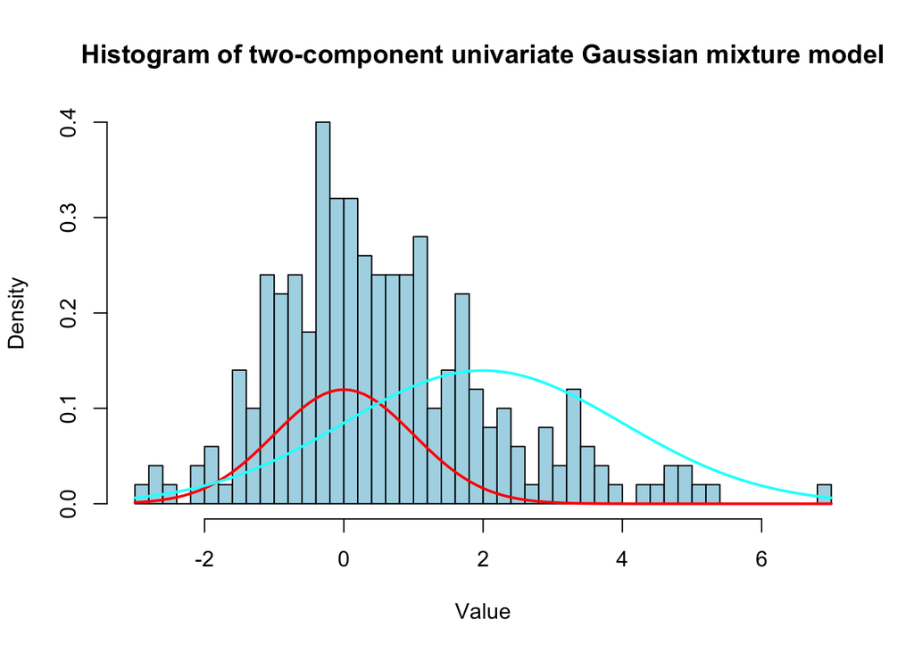

```r
plot_data_GMM(data = data_nodes[[2]], K, params) # data node 2
```

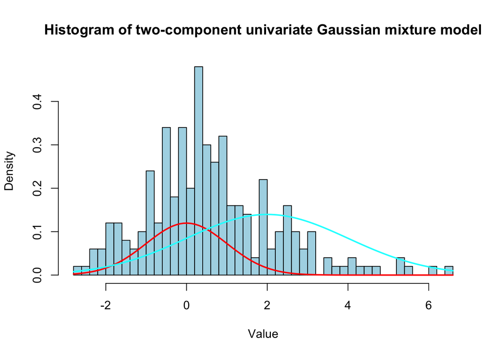

```r
plot_data_GMM(data = data_nodes[[3]], K, params) # data node 3
```

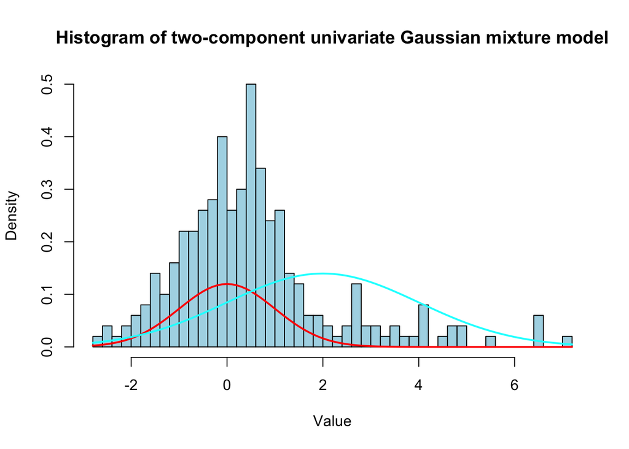

```r
plot_data_GMM(data = data_nodes[[4]], K, params) # data node 4
```

```r
plot_data_GMM(data = unlist(data_nodes), K, params) # all data
```

[output not shown]

## Functions to get local sufficient statistics

Functions:

1. calculate_data_belonings
2. calculate_node_local_sufficient_statistics

### calculate_data_belongings

- Used on each worker node
- Calculates the data points conditional component belongings (probabilities) based on the data and the current parameter estimates
- For each data point $\sum_k^K \pi_k = 1$ and $\pi_k \in [0, 1]$

```r
calculate_data_belongings <- function(params, data){


  ### Extracting parameters and checking if they are they same.
  means <- params$means
  stds <- params$stds
  probs <- params$mixing_probs
  if (length(means) != length(stds) || length(means) != length(probs)){
    stop("Number of means, standard deviations, and weights must be equal.")
  }

  ### Get the data sample and number of components
  n_components <- length(means)
  n <- length(data)

  ### Calculating the belongings
  gamma_num <- matrix(nrow = n, ncol = n_components)
  for(i in 1:n_components){
    gamma_num[,i] <- probs[i] * dnorm(data, mean = means[i], sd = stds[i])
  }
  gamma_den <- rowSums(gamma_num)
  gamma <- gamma_num / gamma_den

  ### Check if data belongings sum to 1 (have grace for rounding errors).
  if (any(abs(rowSums(gamma) - 1) > .Machine$double.eps * n)){
      stop("Calculated belongings for each data point do not sum to 1.")
  }

  ### Check if any data belonging is negative
  if (any(gamma < 0)){
      stop("Calculated belongings contain negative values.")
  }
  return(gamma)
}

### test (vectorisation)
# lapply(1:m, function(x) calculate_data_belongings(params = params_init, data = data_nodes[[x]]))
#
# ### try parallel
# cl <- makeCluster(4, type = "PSOCK")
# clusterExport(cl, "params_init")
# clusterExport(cl, "calculate_data_belongings")
# data_belongings <- parLapply(cl, data_nodes, function(d) {
#     calculate_data_belongings(data = d, params = params_init)
# })
# data_belongings
# stopCluster(cl)
```

### calculate_node_local_sufficient_statistics

- Used on worker nodes.
- For each worker node it calculates the nodes respective local sufficient statistics
  $$\begin{equation}
  \begin{split}
  a_{m,k}^t & = \sum_{i=1}^{N_m} \gamma_{m,i,k}^{t} \\
  b_{m,k}^t & = \sum_{i=1}^{N_m} \gamma_{m,i,k}^{t}y_{m,i} \\
  c_{m,k}^t & = \sum_{i=1}^{N_m} \gamma_{m,i,k}^{t}y_{m,i}^2
  \end{split}
  \end{equation}$$

```r
calculate_node_local_sufficient_statistics <- function(data, params){
    ### Calculating the data belongings
    belongings <- calculate_data_belongings(params = params, data = data)

    ### Calculating the local sufficient statistics for the node
    #### Number 1: sum of data belongings
    sufficient_stat_one <- colSums(belongings)

    #### Number 2: sum of product (data and data belongings)
    sufficient_stat_two <- colSums(belongings * matrix(data, nrow = length(data), ncol = ncol(belongings), byrow = FALSE))

    #### Number 3: sum of product (data squared and data belongings)
    sufficient_stat_three <- colSums(belongings * matrix(data^2, nrow = length(data), ncol = ncol(belongings), byrow = FALSE))

    if(any(sufficient_stat_three < 0)){
        stop("Third sufficient statistic is negative")
    }
    return(list("suff_stat_one" = sufficient_stat_one,
                "suff_stat_two" = sufficient_stat_two,
                "suff_stat_three" = sufficient_stat_three)
    )
}

### test (vectorisation)
# m <- 4
# lapply(1:m, function(x) calculate_node_local_sufficient_statistics(data = data_nodes[[x]], params = params_init))
```

## Functions to get updated parameter estimates

Functions:

1. calculate_global_statistics (sum local statistics)
2. estimate_parameters

### calculate_global_statistics

- done on manager node
- gets the local statistics calculated on each node and sums them together to the global statistics

```r
calculate_global_statistics <- function(...){
    local_statistics <- list(...)

    global_suff_stat_one <- NULL
    global_suff_stat_two <- NULL
    global_suff_stat_three <- NULL

    for(local_stat in local_statistics){
        if(is.null(global_suff_stat_one)){
            global_suff_stat_one <- local_stat$suff_stat_one
            global_suff_stat_two <- local_stat$suff_stat_two
            global_suff_stat_three <- local_stat$suff_stat_three
        } else{
            global_suff_stat_one <- global_suff_stat_one + local_stat$suff_stat_one
            global_suff_stat_two <- global_suff_stat_two + local_stat$suff_stat_two
            global_suff_stat_three <- global_suff_stat_three + local_stat$suff_stat_three
        }
    }

    if(sum(global_suff_stat_one) <= 0){
        stop("The sum of the first global sufficient statistics must be positi`ve")
    }

    if(any(global_suff_stat_three < 0)){
        stop("Third global sufficient statistics is negative")
    }
    return(list("global_suff_stat_one" = global_suff_stat_one,
                "global_suff_stat_two" = global_suff_stat_two,
                "global_suff_stat_three" = global_suff_stat_three))
}

### Test
local_suff_node_1 <- calculate_node_local_sufficient_statistics(
    data = data_nodes[[1]],
    params = params_init
)
local_suff_node_2 <- calculate_node_local_sufficient_statistics(
    data = data_nodes[[2]],
    params = params_init
)
local_suff_node_3 <- calculate_node_local_sufficient_statistics(
    data = data_nodes[[3]],
    params = params_init
)
local_suff_node_4 <- calculate_node_local_sufficient_statistics(
    data = data_nodes[[4]],
    params = params_init
)

# calculate_global_statistics(local_suff_node_1, local_suff_node_2,
                            # local_suff_node_3, local_suff_node_4)
```

### estimate_parameters

- done on manager node
- updates the GMM parameter estimates using the global sufficient statistics

$$\begin{equation}
\begin{split}
\pi_k & = \frac{a_k^t}{\sum_{k}^{K}a_k^t} \\
\mu_k & = \frac{b_k^t}{a_k^t} \\
\sigma_k & = \sqrt{\frac{c_k^t}{a_k^t} - \mu_k^2}
\end{split}
\end{equation}$$

```r
estimate_parameters <- function(global_sufficient_statistics) {

    # Initialize vectors for means, standard deviations, and probabilities
    means <- numeric(length(global_sufficient_statistics$global_suff_stat_one))
    stds <- numeric(length(global_sufficient_statistics$global_suff_stat_one))
    probs <- numeric(length(global_sufficient_statistics$global_suff_stat_one))

    for (k in 1:length(global_sufficient_statistics$global_suff_stat_one)) {
        mean <- global_sufficient_statistics$global_suff_stat_two[k] / global_sufficient_statistics$global_suff_stat_one[k]
        var <- (global_sufficient_statistics$global_suff_stat_three[k] / global_sufficient_statistics$global_suff_stat_one[k]) - (mean^2)
        std <- sqrt(var)
        prob <- global_sufficient_statistics$global_suff_stat_one[k] / sum(global_sufficient_statistics$global_suff_stat_one)

        # Assign calculated values to the respective vectors
        means[k] <- mean
        stds[k] <- std
        probs[k] <- prob
    }

    return(list("mixing_probs" = probs,
                "means" = means,
                "stds" = stds))
}

### Test
# global_sufficient_statistics <- calculate_global_statistics(local_suff_node_1, local_suff_node_2,
#                             local_suff_node_3, local_suff_node_4)
# print("Estimate")
# estimates <- estimate_parameters(global_sufficient_statistics = global_sufficient_statistics)
# estimates
# print("True")
# params
```

## Test full code (using vectorisation)

Run the code in a a full GMM setting. Using vectorisation calculate data belongings and local sufficient statistics (functions that run on the worker nodes).

Functions:

1. GMM_using_vectorisation
2. calculate_log_likelihood (need to figure out a way to calculate this using sufficient statistics)

### calculate_log_likelihood

- calculates the current log likelihood given the data and current parameter estimates

```r
calculate_likelihood <- function(data, params) {
    mu <- params$means
    sigma <- params$stds
    weight <- params$mixing_probs
    k <- length(mu)
    n <- length(data)
    likelihood <- numeric(n)
    for (i in 1:n) {
        point_likelihood <- 0
        for (j in 1:k) {
            component_density <- weight[j] * dnorm(data[i], mean = mu[j], sd = sigma[j])
            point_likelihood <- point_likelihood + component_density
        }
        likelihood[i] <- point_likelihood
    }
    return(sum(log(likelihood)))
}

### Test
# print("loglikelihood with initial estimates")
# calculate_likelihood(data = unlist(data_nodes), params = params_init)
# print("loglikelihood with first updated estimates")
# calculate_likelihood(data = unlist(data_nodes), params = estimates)
```

```r
GMM_using_vectorisation <- function(data,
                                    tol = 0.05,
                                    max_iter = 1000,
                                    params_init){
    parameters <- params_init
    full_data <- unlist(data)

    iteration <- 0
    log_likelihood_old <- calculate_likelihood(data = full_data,
                                               params = parameters)
    likelihood_performance <- cbind(iteration, log_likelihood_old)
    print(likelihood_performance)

    log_likelihood_diff <- 100000
    while(log_likelihood_diff > 0.05){
        iteration <- iteration + 1
        # E-step (done on workers)
        local_sufficient_statistics <- lapply(1:m,
                                              function(x) calculate_node_local_sufficient_statistics(data=data_nodes[[x]],
                                                                                                     params = params_init))
        # Get global sufficient statistics (manager node)
        global_sufficient_statistics <- calculate_global_statistics(local_node_1 <- local_sufficient_statistics[[1]],
                                                                    local_node_2 <- local_sufficient_statistics[[2]],
                                                                    local_node_3 <- local_sufficient_statistics[[3]],
                                                                    local_node_4 <- local_sufficient_statistics[[4]])

        # Update parameters
        parameters <- estimate_parameters(global_sufficient_statistics = global_sufficient_statistics)
        log_likelihood_new <- calculate_likelihood(data = full_data,
                                                   params = parameters)
        likelihood_performance <- rbind(likelihood_performance, cbind(
            iteration, log_likelihood_new
        ))
        log_likelihood_diff <- abs(log_likelihood_new - log_likelihood_old)
        if (log_likelihood_new < log_likelihood_old){
            'Montonicity is not being met'
        }
        log_likelihood_old <- log_likelihood_new
    }
    return(list("parameters" = parameters,
                "performance" = likelihood_performance))

}

### Test
results <- GMM_using_vectorisation(data = data_nodes,
                                   params_init = params_init)
```

```
##      iteration log_likelihood_old
## [1,]         0          -1902.255
```

```r
results$parameters
```

```
## $mixing_probs
## [1] 0.5439366 0.4560634
##
## $means
## [1] -0.06083703  1.32743885
##
## $stds
## [1] 1.004990 1.896372
```

```r
results$performance
```

```
##      iteration log_likelihood_old
## [1,]         0          -1902.255
## [2,]         1          -1844.905
## [3,]         2          -1844.905
```

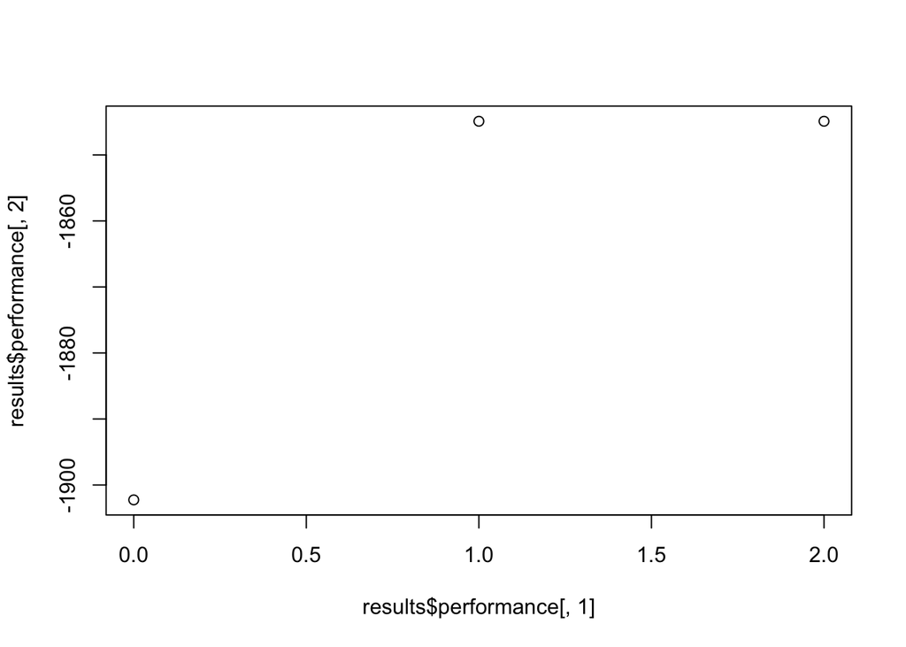

```r
plot(x = results$performance[,1],
     y = results$performance[,2])
```

```r
plot_data_GMM(data = unlist(data_nodes), K, params) # true values
```

[output not shown]

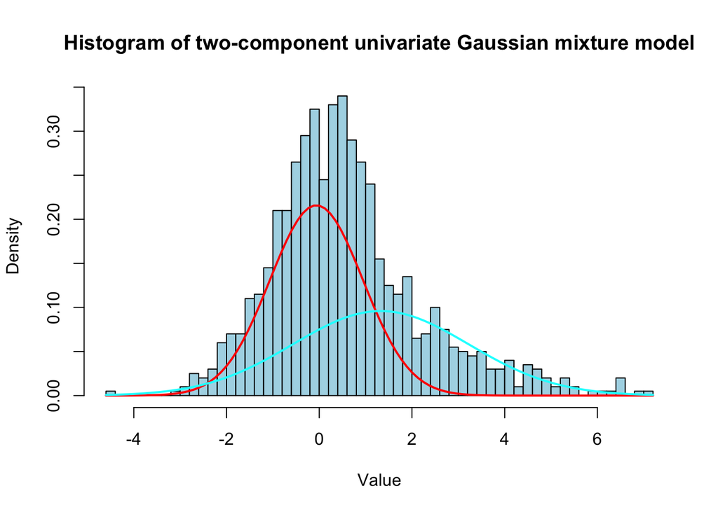

```r
plot_data_GMM(data = unlist(data_nodes), K, results$parameters) # estimates
```

## GMM using parallel computing